# 데이터 과학 – 금융(Finance)

S&P 신용등급

xwMOOC

Tidyverse Korea

2019-01-16

# 1 국가 신용등급

위키백과사전에서 [List of countries by credit rating](https://en.wikipedia.org/wiki/List_of_countries_by_credit_rating) 데이터를 다운로드 받는다.

## 1.1 S&P 국가 신용등급

Standard & Poor’s (S&P)에서는 `BBB-`이상이 투자등급, `BB+`이하는 투기등급으로 정의한다.

```r
library(tidyverse)
library(rvest)
library(janitor)

rating_url <- "https://en.wikipedia.org/wiki/List_of_countries_by_credit_rating"

snp_dat <- rating_url %>%
  read_html() %>%
  html_node(xpath='//*[@id="mw-content-text"]/div/table[1]') %>%
  html_table() %>%
  tbl_df

snp_df <- snp_dat %>%
  clean_names() %>%
  rename(country = country_region) %>%
  separate(rating, into=c("tmp", "rating"), sep=" ") %>%
  select(country, date, outlook, rating) %>%
  mutate(date = lubridate::ymd(date)) %>%
  mutate(rating = factor(rating, levels = c("AAA","AA+","AA","AA-","A+","A","A-","BBB+","BBB","BBB-","BB+","BB","BB-","B+","B","B-","CCC+","D","SD")))

snp_df %>%
  DT::datatable()
```

|  | country | date | outlook | rating |
| --- | --- | --- | --- | --- |
| 1 | Abu Dhabi, UAE | 2012-02-20 | Stable | AA |
| 2 | Albania | 2012-02-20 | Stable | B+ |
| 3 | Andorra | 2016-07-29 | Stable | BBB- |
| 4 | Angola | 2016-08-12 | Stable | B- |
| 5 | Argentina | 2018-11-13 | Stable | B |
| 6 | Aruba | 2016-06-06 | Positive | BBB+ |
| 7 | Australia | 2016-07-06 | Stable | AAA |
| 8 | Austria | 2013-01-29 | Stable | AA+ |
| 9 | Azerbaijan | 2016-07-29 | Negative | BB+ |
| 10 | Bahamas | 2016-12-20 | Stable | BB+ |

[output cut: 121 more lines]

앞서 신용등급변수(`rating`)을 요인(factor) 변수로 변환시켰기 때문에 가장 높은 등급부터 가장 낮은 등급까지 자연스럽게 `rating` 등급표를 쉽게 작성할 수 있따.

```r
snp_df %>%
  count(rating)
```

```
# A tibble: 19 x 2
   rating     n
   <fct>  <int>
 1 AAA       11
 2 AA+        4
 3 AA         8
 4 AA-        7
 5 A+         7
 6 A          3
 7 A-         9
 8 BBB+       6
 9 BBB        6
10 BBB-      11
11 BB+        5
12 BB         4
13 BB-        9
14 B+        13
15 B         13
16 B-        12
17 CCC+       1
18 D          1
19 SD         1
```

## 1.2 피치 국가 신용등급

피치 (Fitch)에서는 `BBB-` 이상이 투자등급, `BB+`이하는 투기등급으로 정의한다.

```r
fitch_dat <- rating_url %>%
  read_html() %>%
  html_node(xpath='//*[@id="mw-content-text"]/div/table[2]') %>%
  html_table() %>%
  tbl_df

fitch_df <- fitch_dat %>%
  clean_names() %>%
  rename(country = country_region) %>%
  mutate(rating = str_remove_all(rating, "[0-9]")) %>%
  select(country, date, outlook, rating) %>%
  mutate(date = lubridate::ymd(date)) %>%
  mutate(rating = factor(rating, levels = c("AAA","AA+","AA","AA-","A+","A","A-","BBB+","BBB","BBB-","BB+","BB","BB-","B+","B","B-","CCC+","D","SD")))

fitch_df %>%
  DT::datatable()
```

|  | country | date | outlook | rating |
| --- | --- | --- | --- | --- |
| 1 | Abu Dhabi | 2011-11-21 | Stable | AA |
| 2 | Angola | 2011-11-21 | Stable | BB- |
| 3 | Argentina | 2016-05-10 | Stable | B |
| 4 | Armenia | 2011-11-21 | Stable | BB- |
| 5 | Aruba | 2016-04-26 | Stable | BBB- |
| 6 | Australia | 2011-11-29 | Stable | AAA |
| 7 | Austria | 2016-02-05 | Stable | AA+ |
| 8 | Azerbaijan | 2011-11-21 | Positive | BBB- |
| 9 | Bangladesh | 2018-01-11 | Stable | BB- |
| 10 | Bahrain | 2011-11-21 | Stable | BBB |

[output cut: 99 more lines]

앞서 신용등급변수(`rating`)을 요인(factor) 변수로 변환시켰기 때문에 가장 높은 등급부터 가장 낮은 등급까지 자연스럽게 `rating` 등급표를 쉽게 작성할 수 있따.

```r
fitch_df %>%
  count(rating)
```

```
# A tibble: 17 x 2
   rating     n
   <fct>  <int>
 1 AAA       11
 2 AA+        4
 3 AA         7
 4 AA-        3
 5 A+         7
 6 A          3
 7 A-         6
 8 BBB+       3
 9 BBB        9
10 BBB-       9
11 BB+        5
12 BB         4
13 BB-       13
14 B+         7
15 B         11
16 B-         4
17 <NA>       3
```

## 1.3 Dagong 국가 신용등급

Dagong은 2018년 China Securities Regulatory Commission (CSRC)에 의해서 영업정지된 것으로 나타난다.

```r
dagong_dat <- rating_url %>%
  read_html() %>%
  html_node(xpath='//*[@id="mw-content-text"]/div/table[7]') %>%
  html_table() %>%
  tbl_df

dagong_df <- dagong_dat %>%
  clean_names() %>%
  mutate(rating = str_remove_all(rating, "[0-9]")) %>%
  select(country, date, outlook, rating) %>%
  mutate(date = if_else(str_length(date) <=8, parse_date(date, "%Y-%m"), lubridate::ymd(date))) %>%
  mutate(rating = factor(rating, levels = c("AAA","AA+","AA","AA-","A+","A","A-","BBB+","BBB","BBB-","BB+","BB","BB-","B+","B","B-","CCC+","D","SD")))

dagong_df %>%
  DT::datatable()
```

|  | country | date | outlook | rating |
| --- | --- | --- | --- | --- |
| 1 | Algeria | 2014-10-01 | Stable | BBB- |
| 2 | Angola | 2013-05-31 | Stable | BB- |
| 3 | Argentina | 2014-07-31 | Negative | D |
| 4 | Australia | 2013-11-01 | Stable | AA+ |
| 5 | Austria | 2014-12-01 | Stable | AA+ |
| 6 | Bahrain | 2014-08-01 | Stable | A- |
| 7 | Bangladesh | 2013-11-01 | Stable | BB- |
| 8 | Belarus | 2014-01-01 | Negative | BB- |
| 9 | Belgium | 2014-10-01 | Stable | A+ |
| 10 | Bolivia | 2013-05-15 | Stable | BBB- |

[output cut: 89 more lines]

앞서 신용등급변수(`rating`)을 요인(factor) 변수로 변환시켰기 때문에 가장 높은 등급부터 가장 낮은 등급까지 자연스럽게 `rating` 등급표를 쉽게 작성할 수 있따.

```r
dagong_df %>%
  count(rating)
```

```
# A tibble: 18 x 2
   rating     n
   <fct>  <int>
 1 AAA        6
 2 AA+        9
 3 AA         3
 4 AA-        6
 5 A+         6
 6 A          3
 7 A-         7
 8 BBB+       6
 9 BBB        8
10 BBB-       8
11 BB+        4
12 BB         3
13 BB-        9
14 B+         2
15 B          5
16 B-         3
17 D          1
18 <NA>      10
```

## 1.4 신용기관 등급 비교

```r
snp_comp_df <- snp_df %>%
  mutate(agency="S&P") %>%
  rename(snp = rating) %>%
  select(country, snp)

fitch_comp_df <- fitch_df %>%
  mutate(agency="Fitch") %>%
  rename(fitch = rating) %>%
  select(country, fitch)

dagong_comp_df <- dagong_df %>%
  mutate(agency="Dagong") %>%
  rename(dagong = rating) %>%
  select(country, dagong)

rating_dat <- full_join(snp_comp_df, fitch_comp_df) %>%
  full_join(dagong_comp_df)

rating_dat %>%
  DT::datatable()
```

|  | country | snp | fitch | dagong |
| --- | --- | --- | --- | --- |
| 1 | Abu Dhabi, UAE | AA |  |  |
| 2 | Albania | B+ |  |  |
| 3 | Andorra | BBB- |  |  |
| 4 | Angola | B- | BB- | BB- |
| 5 | Argentina | B | B | D |
| 6 | Aruba | BBB+ | BBB- |  |
| 7 | Australia | AAA | AAA | AA+ |
| 8 | Austria | AA+ | AA+ | AA+ |
| 9 | Azerbaijan | BB+ | BBB- |  |
| 10 | Bahamas | BB+ |  |  |

[output cut: 144 more lines]

앞서 신용등급변수(`rating`)을 요인(factor) 변수로 변환시켰기 때문에 가장 높은 등급부터 가장 낮은 등급까지 자연스럽게 `rating` 등급표를 쉽게 작성할 수 있다.

```r
rating_df <- rating_dat %>%
  filter(complete.cases(.))

rating_df %>%
  gather(agency, rating, -country) %>%
  count(rating, agency) %>%
  mutate(rating = factor(rating, levels = c("AAA","AA+","AA","AA-","A+","A","A-","BBB+","BBB","BBB-","BB+","BB","BB-","B+","B","B-","CCC+","D"))) %>%
  spread(agency, n)
```

```
# A tibble: 17 x 4
   rating dagong fitch   snp
   <fct>   <int> <int> <int>
 1 AAA         6    11    10
 2 AA+         8     3     4
 3 AA          3     6     6
 4 AA-         3     3     4
 5 A+          6     6     4
 6 A           2     2     2
 7 A-          7     5     6
 8 BBB+        4     3     3
 9 BBB         6     9     5
10 BBB-        7     5     8
11 BB+         3     2     2
12 BB          2     3     2
13 BB-         7     5     5
14 B+          2     5     3
15 B           3     3     4
16 B-          2     1     4
17 D           1    NA    NA
```

신용등급별로 신용평가사 평가한 국가별 빈도를 막대그래프로 시각화한다.

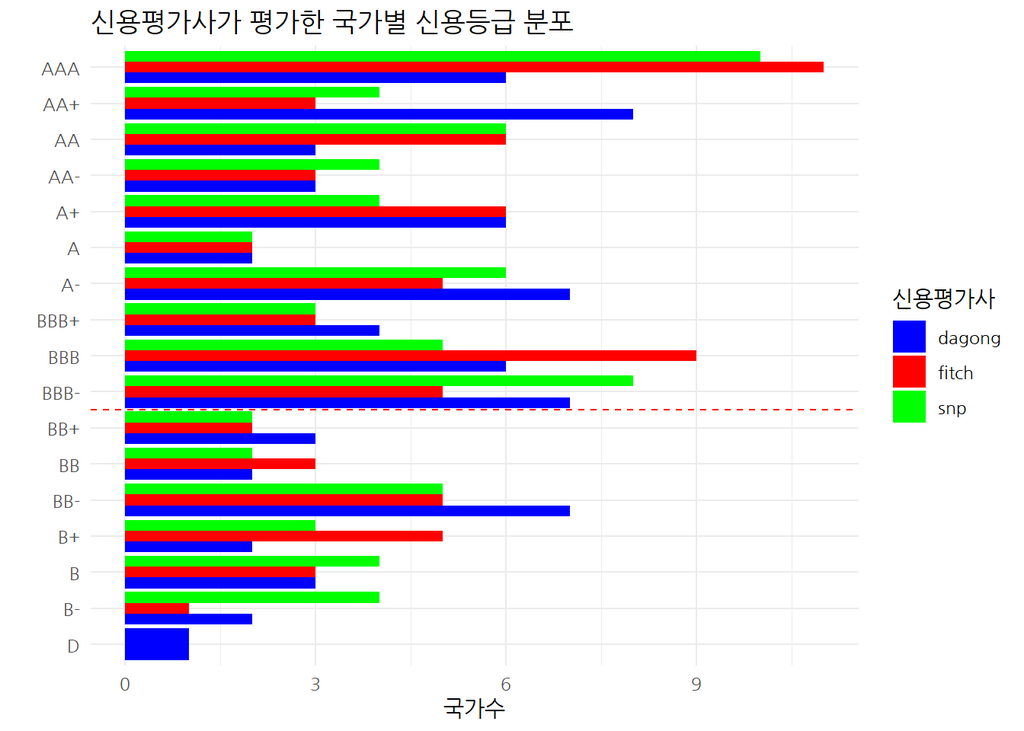

```r
library(extrafont)
loadfonts()

rating_df %>%
  gather(agency, rating, -country) %>%
  count(rating, agency) %>%
  mutate(rating = factor(rating, levels = c("AAA","AA+","AA","AA-","A+","A","A-","BBB+","BBB","BBB-","BB+","BB","BB-","B+","B","B-","CCC+","D"))) %>%
  ggplot(aes(x=fct_rev(rating), y=n, fill=agency)) +
    geom_col(position="dodge") +
    labs(x="", y="국가수", fill="신용평가사", title="신용평가사가 평가한 국가별 신용등급 분포") +
    theme(legend.position = "top") +
    theme_minimal(base_family = "NanumGothic") +
    geom_vline(xintercept = 7.5, color="red", linetype="dashed") +
    coord_flip()  +
    scale_fill_manual(values = c("blue", "red", "green"))
```